# bcl_415222769.htm

[figure not shown]

O ambiente R

Ambiente e linguagem para programação estatística e de gráficos

O termo “ambiente” pretende caracterizar R como um sistema totalmente planejado e coerente

Permite criar ferramentas, montar rotinas de trabalho, Flexível.

[figure not shown]

Linguagem R

|  | Linguagem de programação | “Gramática” |  |
| --- | --- | --- | --- |
|  |  | Linguagem orientada à objetos |  |
|  |  |  | Objetos |

| x <- 1:10 |  |  |  |  |  |  |  |  |  |
| --- | --- | --- | --- | --- | --- | --- | --- | --- | --- |
| x |  |  |  |  |  |  |  |  |  |
| [1] | 1 | 2 | 3 | 4 | 5 | 6 | 7 | 8 | 9 10 |

|  | VETORES |
| --- | --- |
| Numeric | 1.1, 2, 3.4, 5, 7.8, 10.8 |
| Integer | 1, 2, 5, 8, 10, 20 |
| Factor | Categorias/níveis |
| Character | Letras, palavras, frases |
| Logical | Verdadeiro/falso |

Matriz, Lista e Data Frame

Matriz: possui linhas e colunas onde apenas números são aceitos;

Lista: é uma coleção de elementos que podem ser de diferentes tipos;

Data Frame: Um caso especial de lista onde todos os elementos têm o mesmo comprimento.

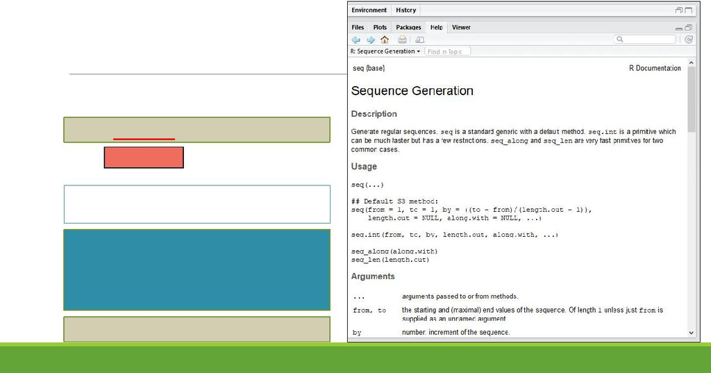

Linguagem R

Funções e Argumentos

seq(From = 1, to = 1000, by=100)

Argumento

Cada argumento é separado por uma vírgula

dentro da função

Ler a Ajuda da função dá detalhes de como

utilizar a função, do que significa cada

argumento, assim como detalhes e exemplos

de uso

?seq

[figure not shown]

| Script | Objetos e histórico |
| --- | --- |

Console

Ajuda, gráficos, arquivos e etc..

[figure not shown]

Iniciando os trabalhos

Sempre confira a pasta de trabalho que o R está:

getwd() – retorna qual é a pasta de trabalho que está sendo utilizada setwd(“Documentos/R”) – configura qual a pasta de trabalho você deseja usar

Evite abusar dos atalhos de mouse.

Manter tudo que você faz em códigos permite que você possa saber exatamente o que fez quando usou da ultima vez.

O Script

Sua rotina de trabalho pode ser reproduzível com um Script;

Ctrl + R (Windows) ou Ctrl + ENTER (Mac ou Linux) executa o comando no Script; Use apenas o ENTER para executar um comando no Console;

Use # para comentar e anotar informações no Script ; Mantenha seu script organizado;

Divida os códigos mais longos em mais de uma linha;

Use o Tab e linhas em branco para dar noção de emblocamento dos códigos

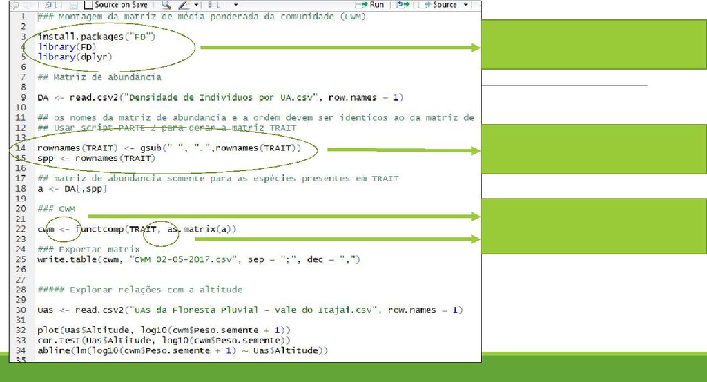

Agrupe a abertura de pacotes no inicio

do Script.

Sequencias de trabalho em bloco.

Espaço antes e depois da seta.

E após virgulas.

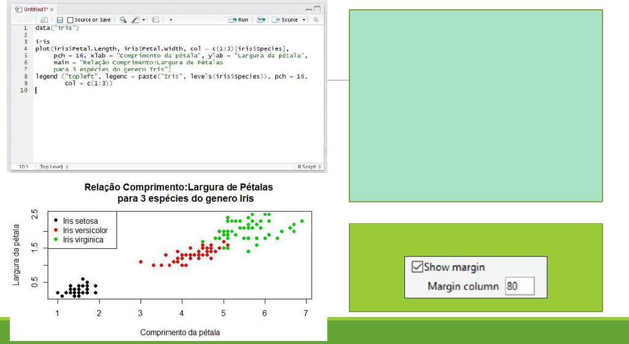

Note que há muitos argumentos utilizados nas

funções plot e legend

Para deixar o código um pouco mais agradável visualmente, pula-se para outra linha após uma virgula.

A vírgula deve estar no fim de uma linha para que

a função seja executada corretamente.

Tools -> Global Options -> Code -> Display

Pacotes

install.packages(“nome_do_pacote”) - Baixa e instala o pacote

library(nome_do_pacote) - Carrega o pacote

Os pacotes contém funções que não existem no base R.

Assim, quando for utilizar uma função no R o pacote que contem a função deve estar carregado. Por isso é comum ver uma lista de pacotes sendo carregados no inicio de um script.

A instalação é feita apenas uma vez.

[figure not shown]

Objetos e o ambiente global

Objetos são gravados na memória RAM (ambiente global)

Criando vetores

Para criar um objeto você deve assinalar um valor à um nome:

obj <- 5

para mais de um valor utilize a função c() ou valores numéricos sequencias são obitidos com simbolo “:”.

obj <- c(2, 3, 4, 5)

ou

obj <- 2:5

Criando vetores

Vetores também podem conter caracteres, eles sempre devem estar entre áspas.

obj <- c("a","b","c")

Crie repetições - Função rep()

Cria repetições

rep(4, 3)

rep(x, 4)

rep(x, each = 4)

rep(c(4, 3), each = 3)

Crie sequencias - Função seq()

Cria sequencias padronizadas.

Sequencia de 1 a 100

seq(1, 100)

Sequencia de 1 a 100 de 10 em 10.

seq(1, 100, by = 10)

Crie valores aleatório (uniformes ou normais)

Para valores aleatórios uniformes:

runif(n, min, max)

runif(10, 0, 2) # dez valores aleatórios entre 0 e 2

Para valores aleatórios de distribuição normal:

rnorm(n, mean, sd)

rnorm (10, 5, 1) # dez valores aleatórios com média 5 e desvio padrão 1

Fixar aleatorização - Função set.seed()

set.seed(12)

rnorm (10, 5, 1)

[1]3.519432 6.577169 4.043256 4.079995 3.002358 4.727704 4.684651 4.371745

[9]4.893536 5.428015

Extrair valores aleatórios - Função sample()

Criando valores aleatórios:

random <- rnorm(10, 5, 1)

Extraindo valores aleatórios:

sample(random, 5)

sample(random, 15)

sample(random, 15, replace = TRUE) #Faz amostras com repetição.

Crie matrizes - função matrix()

Matrizes aceitam apenas valores numéricos e possuiem duas dimensões (linhas e colunas)

matrix(data, nrow, ncol) matrix(1:20, 10, 2)

matrix(c(a, 20:29), 10, 2)

Crie data frames - função data.frame()

Data frames aceitam qualquer tipo de valor (numérico, caracter, lógico). Os valores devem ter o mesmo comprimento

data.frame (a, b, z) #utilizou os objetos já criados para criar um data frame

data.frame (c(1:20), a, b) # identifique o erro

Crie listas - Função list()

Listas podem ser compostas por elementos de diferentes tamanhos. è a maneira mais usual de funções retornarem valores.

list(dados, b, x) # utilizou objetos já criados para gerar uma lista

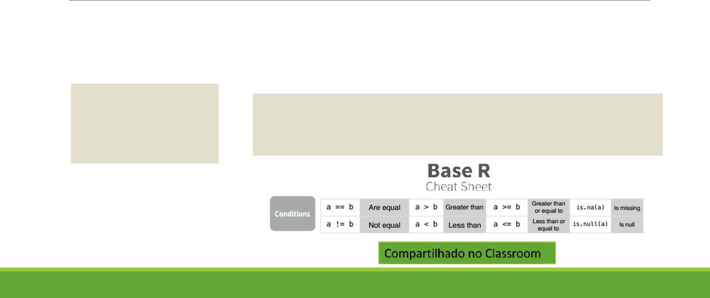

Selecionando valores de objetos vetores

Conchetes [] são usados para selecionar valores de um objeto.

Execute as funções abaixo:

dim(a)

class(a)

a[5] # Para selecionar o quinto valor valor

a[a>2] #Selecionar de acordo com uma condição lógica (valores contidos em a maior que 2)

length(a)

[figure not shown]

Selecionando valores em matrizes e data frames

objeto[linha,coluna]

Objeto Matriz

dados[ ,2]

dados[3,1]

dados[8, ]

Objeto Data frame

dados[ ,3]

dados[ ,"z"]

dados[3,1]dados$z dados[3,"a"]

dados[8, ] dados['nome_da_linha', ]

[figure not shown]

Selecionando valores em listas

objeto$nome_elemento objeto[[1]] objeto[[1]][2]

Exemplo:

lista <- list(dados, dados1, b, x) names(lista)

names(lista) <- c("dados", "dados1", "b", "x")

Comandos úteis

class(x) # classe do objeto str(x) # Estrutura do objeto dim(x) # Dimensões do objeto

length(x) # Comprimento do objeto

names(x) # Nomes contidos num objeto vetor, data.frame ou lista rownames(x) # Nomes das linhas em um data frame